# Miguel Angel Gonzalez Jimenez

Hoja de vida

Autor/a

Miguel Angel Gonzalez jimenez

Fecha de publicación

5 de abril de 2024

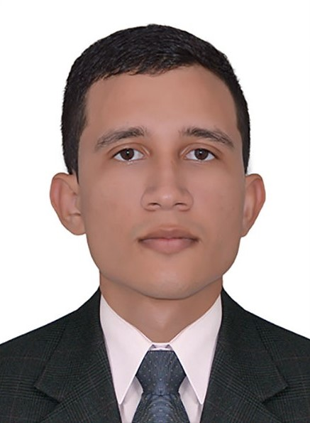

## PERFIL PROFESIONAL

Ingeniero mecánico, estudiante de maestría en Ingenieria mecánica, técnico en mecanizado de productos metalmecánicos, técnico laboral en mantenimiento electromecánico. Cuatro (4) años de experiencia en modelado y diseño mecánico utilizando métodos de elementos finitos. Experiencia en la gestión de proyectos, cumplimiento de cronogramas, reuniones con clientes y manejo de personal. Habilidades en metrología y gestión de software de diseño como AutoCAD, SolidWorks, Autodesk Inventor, Inventor Nastran. Habilidades en la elaboración e interpretación de planos. Conocimientos en parametrización de modelados 3D a través de la herramienta i-logic en Autodesk Inventor. Conocimientos básicos en manejo de máquinas herramienta convencionales y CNC (torno, fresadora, cepillo). Experiencia en docencia.

Siete certificaciones en SolidWorks: CSWA, CSWA Simulation, CSWP, CSWP Drawing Tools, CSWP Weldment Profiles, CSWP Sheet Metal, CSWP Simulation.

## EXPERIENCIA LABORAL

### Ingeniero de proyectos.

Lugar: Universidad del norte, Puerto Colombia, Atlántico, Colombia.

Fecha: 27 de octubre de 2022 – Actualmente.

Resumen: Ingeniero de proyecto y asistente de investigación en diversos proyectos de consultoría UniversidadEmpresa. En los cuales me desempeño realizando funciones de diseñador mecánico, análisis de elementos finitos, gestión de proyectos, creación de cronogramas. Proyectos en diseño estructural, diseño mecánico, análisis de falla, transporte de hidrogeno H2.

### Docente catedrático.

Lugar: Universidad del norte, Puerto Colombia, Atlántico, Colombia.

Fecha: enero 2023- diciembre 2023.

Resumen: catedrático en la asignatura Transferencia de calor.

### Diseñador de Proyectos.

Lugar: SuperBrix, Galapa, Atlántico, Colombia.

Fecha: 25 de octubre de 2021 – 30 de Julio de 2022.

Resumen: Diseñador de proyectos desde su etapa conceptual hasta etapa de detalle, realización de análisis de elementos finitos y planos de fabricación. Visita en plantas de clientes, manejo de reuniones. Software SolidWorks.

- Diseñador líder proyecto Secado de arroz.

- Diseñador líder proyecto Planta alimentos balanceados 500.000 Ton/año.

### Ingeniero De Diseño y Desarrollo.

Lugar: Tecnomedición S.A.S, Bogotá, Cundinamarca, Colombia.

Fecha: 04 de mayo de 2021 - 03 de julio de 2021.

Resumen: Contrato por proyecto de diseño de gasificador para una planta de generación de energía a través de Syngas, uso de Software Autodesk Inventor e Inventor Nastran.

### Ingeniero De Diseño

Lugar: CADMASTER S.A.S, Barranquilla, Atlántico, Colombia.

Fecha: 03 de agosto de 2020- 20 de abril de 2021.

Resumen: Diseño mecánico por elementos finitos (Autodesk Inventor, Inventor Nastran), planos de fabricación de estructuras metálicas, cotizaciones de estructuras metálicas, levantamiento metrológico.

### Practicante Ingenieria Mecánica

Lugar: Relianz Mining Solutions, Galapa, Atlantico, Colombia. Área: Departamento de Ingenieria.

Fecha: 10 Junio de 2019 - 09 Diciembre de 2019.

Resumen: Diseño mecánico por elementos finitos (SolidWorks), planos de fabricación de estructuras metálicas y componentes Caterpillar, levantamiento metrológico de estructuras metálicas, Nesting de cortes.

## FORMACION ACADEMICA

### Programa académico de postgrado

#### Estudiante Maestría en Ingenieria Mecánica

Enero 2023- Actualmente

Universidad del Norte Barranquilla, Colombia.

### Programa académico de pregrado

#### Ingenieria Mecánica

2015-2020

Universidad del Norte Barranquilla, Colombia.

### Técnicos

#### Técnico en mecanizado de productos metalmecánicos

2013-2014

SENA

#### Técnico laboral en mantenimiento electromecánico

2013-2014

Instituto tecnológico de Soledad Atlántico, ITSA

### Bachillerato

#### Bachiller Técnico Industrial (Especialidad de mecánica industrial)

2014

Instituto técnico Industrial Del Atlántico Blas Torre De La Torre, ITIDA.

## FORMACION COMPLEMENTARIA

- VIII Nivel de Inglés. Universidad del Norte.
- Manejo de herramientas informáticas: Solid Edge. SENA
- Metalurgia: Propiedades y clasificación de los principales metales. SENA
- AutoCAD 2D. SENA
- AutoCAD 3D. SENA
- Mentalidad de líder. SENA
- Interpretación de planos 1: Medidas, Escalas y Dibujo. SENA
- Programación de dispositivos móviles. SENA
- Curso especial en salud ocupacional y seguridad industrial. SENA
- Fundamentación de ensamble y mantenimiento de computadores para los procesos de soporte técnico. SENA
- Metrología: patrones instrumentos y tolerancias. SENA
- OEA – Seguridad de la información. Instituto técnico para el trabajo Relianz.
- Machine Design Part I. Georgia Institute of Technology.
- Cinturón Verde Taekwondo.

## COMPETENCIAS

- Análisis y solución de Problemas.
- Comunicación asertiva.
- Habilidades de trabajo en equipo.
- Adaptación cultural.

## IDIOMAS

Ingles Intermedio B1/B2.

## HERRAMIENTAS COMPUTACIONALES

SolidWorks, AutoCAD, Matlab, Office, Autodesk Inventor, Inventor Nastran.

## HOBBIES Y ACTIVIDADES EXTRACURRICULARES

Amante a caminatas por naturaleza.

## DISTINCIONES Y RECONOCIMIENTOS

- Premio “Andrés Bello” en Matemáticas. (2014).
- Mejor estudiante del aula de secundaria, Colegio ITIDA (2014).
- Mejor en la especialidad de mecánica Industrial, Colegio ITIDA (2014).
- Beca Ser Pilo Paga 1 (2014).
- Estudiante distinguido, Universidad Del Norte. Promedio acumulado de 4.09/5.